# Divvy Bikes Analysis

Dan McDonough

September 14, 2021

For this analysis, I’ve used the popular Divvy Bike data set made available by the city of Chicago: https://divvy-tripdata.s3.amazonaws.com/index.html.

The purpose of the analysis is to forecast ridership.

### Data Prep

I will analyze 2017-2018 bike rides and predict rides in 2019.

```r
library(dplyr)
library(forecast)
library(TSPred)
library(aTSA)
library(fGarch)
library(prophet)

datapath <- 'C:/Users/Dan/Desktop/Documents/Misc Documents/Other/Code Projects/divvy/'

# some prepocessing of the individual data files has been removed for readability
df <- read.csv(paste0(datapath,'bikes.csv'))

train <- df[df$Year<2019,]
test <- df[df$Year==2019,]

rm(df)
gc()
```

```
##             used   (Mb) gc trigger   (Mb)  max used   (Mb)
## Ncells  21507873 1148.7   61991790 3310.8  32759124 1749.6
## Vcells 244658387 1866.6  692494902 5283.4 691913902 5278.9
```

```r
daily_df <- as.data.frame(train%>%group_by(Year,startmonth,startday)%>%summarise(trips=n()))
daily_test_df <- as.data.frame(test%>%group_by(Year,startmonth,startday)%>%summarise(trips=n()))

head(daily_df,10)
```

```
##    Year startmonth startday trips
## 1  2017          1        1  1727
## 2  2017          1        2  1960
## 3  2017          1        3  4537
## 4  2017          1        4  3269
## 5  2017          1        5  2917
## 6  2017          1        6  2516
## 7  2017          1        7  1330
## 8  2017          1        8  1193
## 9  2017          1        9  3816
## 10 2017          1       10  3310
```

There is no surprise to see a very clear annual seasonal trend for riding a divvy bike in Chicago.

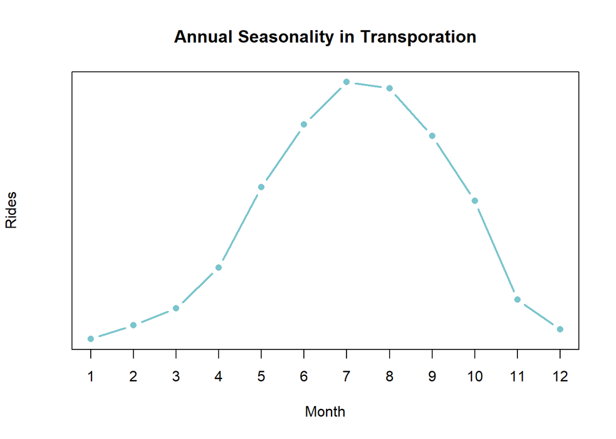

What’s also interesting is that there appears to be a clear weekly commuter trend as well.

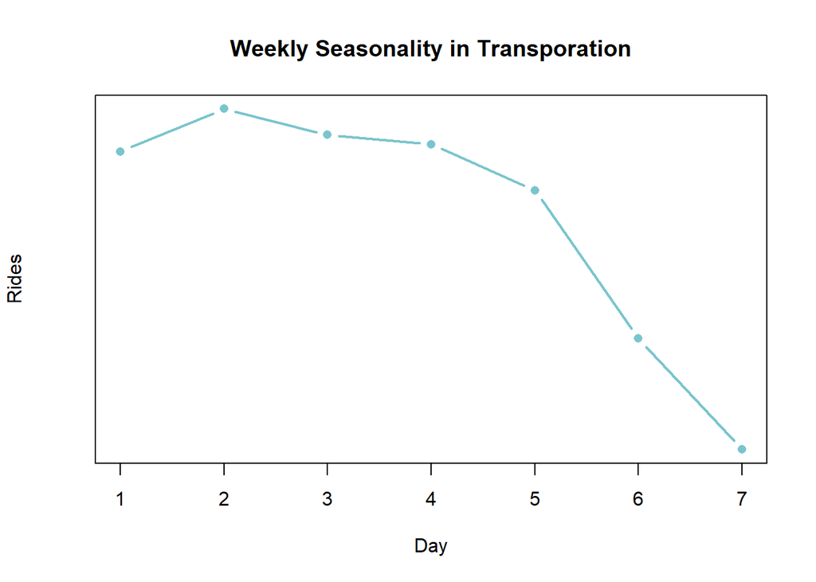

### Models

I started with some ARIMA modeling. The model was unable to pick up on either of the seasonal trends, and did not provide a useful prediction.

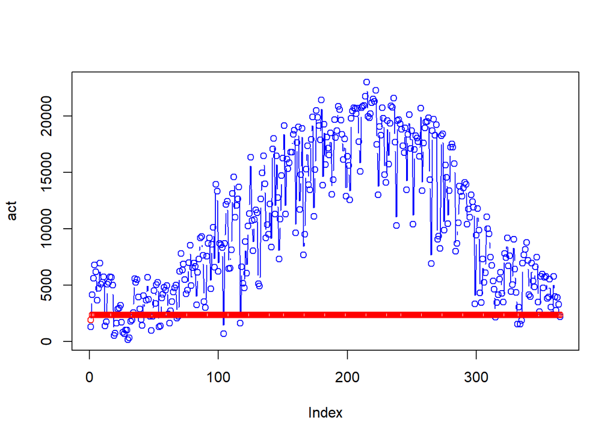

```r
model <- auto.arima(daily_df$trips)

pred <- as.data.frame(forecast::forecast(model,h=365))$`Point Forecast`
act <- daily_test_df$trips

plot(act,col='blue',type='b')
points(pred,col='red',type='b')
```

```r
round(sMAPE(act[1:365],pred),2)
```

```
## [1] 1.09
```

Next I ran a holt winters model, which captured the weekly seasonality but failed to capture the annual component.

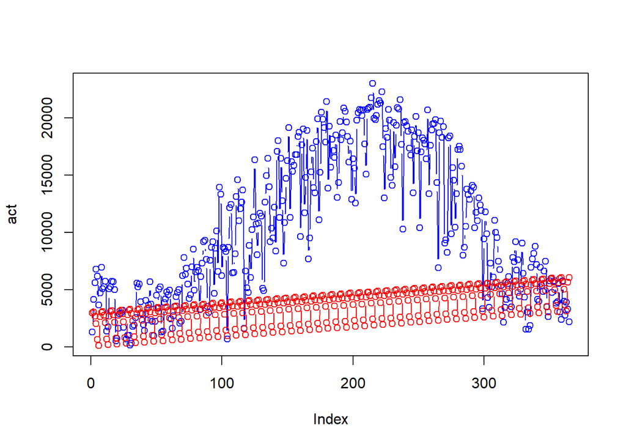

```r
model <- HoltWinters(ts(daily_df$trips,frequency=7))

pred <- as.data.frame(forecast::forecast(model,h=365))$`Point Forecast`
act <- daily_test_df$trips

plot(act,col='blue',type='b')
points(pred,col='red',type='b')
```

```r
round(sMAPE(act[1:365],pred),2)
```

```
## [1] 0.9
```

After this is the ARFIMA model, which appears to mistake the annual seasonality for a positive trend.

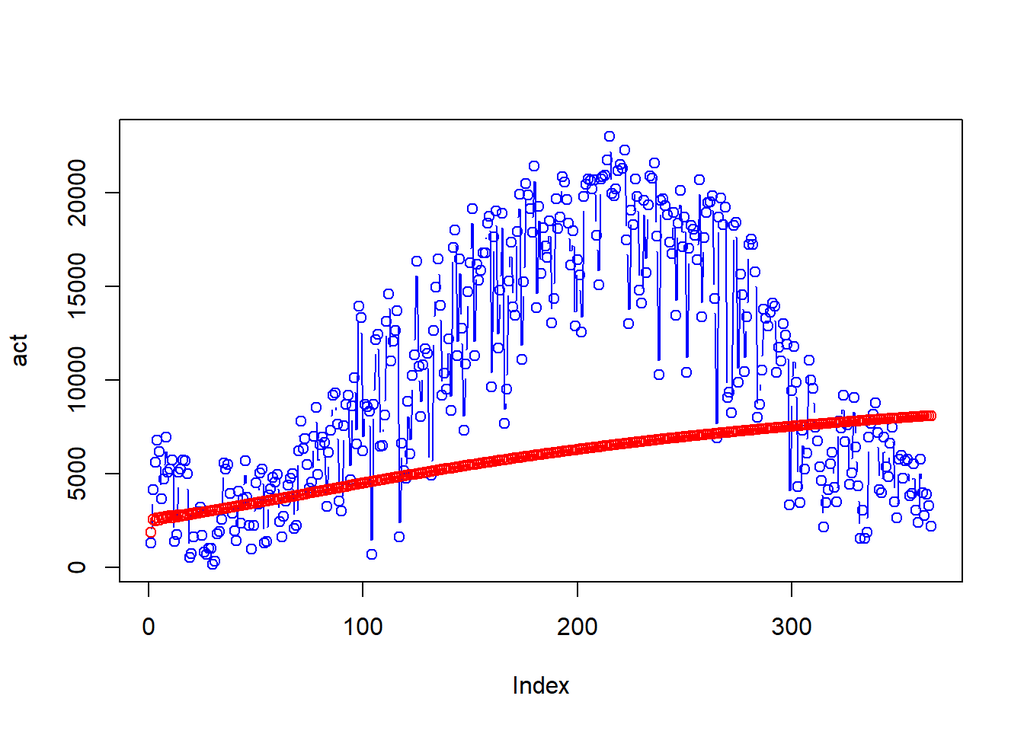

```r
model <- arfima(daily_df$trips)

pred <- as.data.frame(forecast::forecast(model,h=365))$`Point Forecast`
act <- daily_test_df$trips

plot(act,col='blue',type='b')
points(pred,col='red',type='b')
```

```r
round(sMAPE(act[1:365],pred),2)
```

```
## [1] 0.66
```

After these models, I switched to Facebook’s prophet model. By specifying model parameters to capture both annual and weekly seasonality, this model has done the best job so far in capturing the complexity of the data.

```r
daily_df$date <- ISOdate(daily_df$Year, daily_df$startmonth,
                              daily_df$startday, 0, 0, 0)
daily_test_df$date <- ISOdate(daily_test_df$Year, daily_test_df$startmonth,
                              daily_test_df$startday, 0, 0, 0)

data <- daily_df[,c('date','trips')]
names(data) <- c('ds','y')
m <- prophet(data, yearly.seasonality = TRUE, weekly.seasonality = TRUE)
```

```
## Disabling daily seasonality. Run prophet with daily.seasonality=TRUE to override this.
```

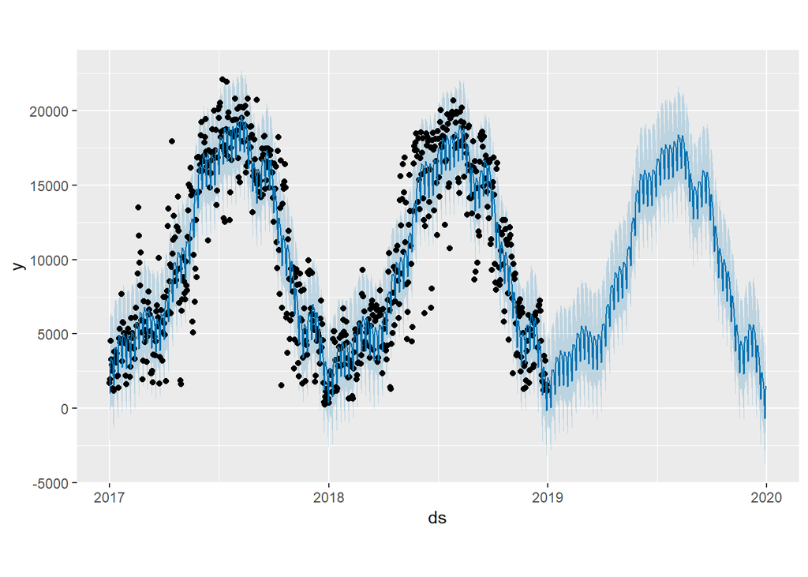

```r
future <- make_future_dataframe(m, periods = 365)
forecast <- predict(m, future)
plot(m, forecast)
```

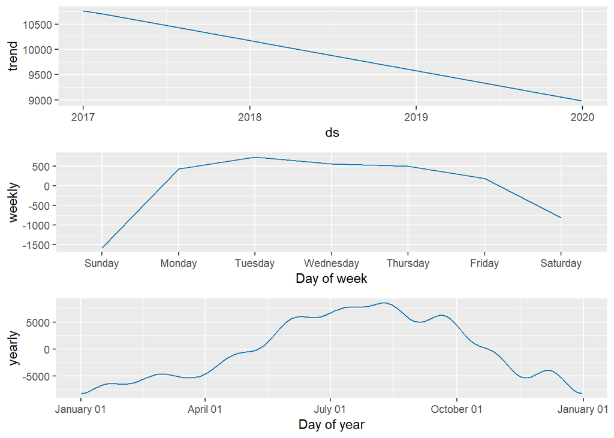

```r
prophet_plot_components(m, forecast)
```

```r
round(sMAPE(daily_test_df$trips,forecast[731:1095,]$yhat),2)
```

```
## [1] 0.35
```

Lastly, I also ran a TBATS model. This model did the best of all and is ideal for picking up multiple seasonalities in time series data.

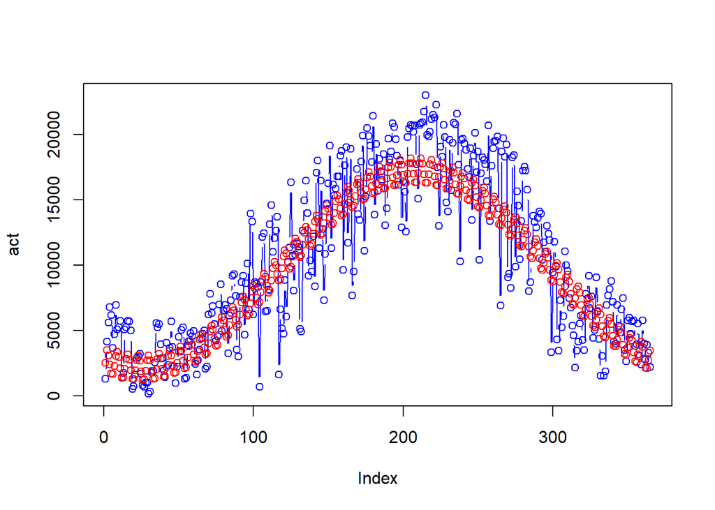

```r
model <- tbats(daily_df$trips,seasonal.periods = c(7,365.25))

pred <- as.data.frame(forecast::forecast(model,h=365))$`Point Forecast`
act <- daily_test_df$trips

plot(act,col='blue',type='b')
points(pred,col='red',type='b')
```

```r
round(sMAPE(act[1:365],pred),2)
```

```
## [1] 0.3
```

### Conclusion

Initally, I envisioned creating model subgroups based on a segmentation of divvy stations, but the submodels failed to outperform the aggregated models, so the overall TBATS model provided the best results. It is worth noting though, that part of TBATS outperforming prophet is the reversal of annual trend going into 2019. Had the trend continued from 2017 into 2018, prophet may have had the best results.